# Praca domowa 2

Jakub Tywonek

## Dane

Dane wykorzystane w Pracy domowej 2 są związane z kampaniami marketingu bezpośredniego portugalskiej instytucji bankowej. Kampanie marketingowe opierały się na rozmowach telefonicznych. Często wymagany był więcej niż jeden kontakt z tym samym klientem, aby uzyskać dostęp do tego, czy produkt (lokata bankowa) zostanie (lub nie) subskrybowany. Opis wszystkich kolumn znajduje się również w pliku `README.md`.

#### Dane klienta banku

| Zmienna | Opis |
| --- | --- |
| **age** | wiek |
| **job** : admin., unknown, unemployed, management, housemaid, entrepreneur, student, blue-collar, self-employed, retired, technician, services | administrator, nieznany, bezrobotny, kierownictwo, pokojówka, przedsiębiorca, student, pracownik fizyczny, samozatrudniony, emeryt, technik, usługi |
| **marital** : married, divorced, single; note: divorced means divorced or widowed) | żonaty/zamężna, rozwiedzion_, kawaler/panna; uwaga: rozwiedzion_ oznacza rozwiedzion_ lub owdowiał_ |
| **education** : unknown, secondary, primary, tertiary | nieznane, średnie, podstawowe, wyższe |
| **default** : yes, no | czy kredyt jest niespłacany : tak, nie |
| **balance** : average yearly balance, in euros | średnie roczne saldo w euro |
| **housing** : has housing loan? yes, no | czy posiada kredyt mieszkaniowy? tak, nie |
| **loan** : has personal loan? yes, no | ma pożyczkę osobistą? tak, nie |

#### Dane związane z ostatnim kontaktem w bieżącej kampanii

| Zmienna | Opis |
| --- | --- |
| **contact** : unknown, telephone, cellular | nieznany, telefon, komórkowy |
| **day** : last contact day of the month | dzień miesiąca ostatniego kontaktu |
| **month** : last contact month of year, jan, feb, mar, …, nov, dec | miesiąc ostatniego kontaktu w roku, styczeń, luty, marzec, …, listopad, grudzień |
| **duration** : last contact duration, in seconds | czas trwania ostatniego kontaktu w sekundach |

## Zadanie 1

Weźmy pod uwagę zawody (`job`) klientów banku. Który zawód zacząco wyróżnia się w posiadaniu kredytu mieszkaniowego lub pożyczki osobistej?

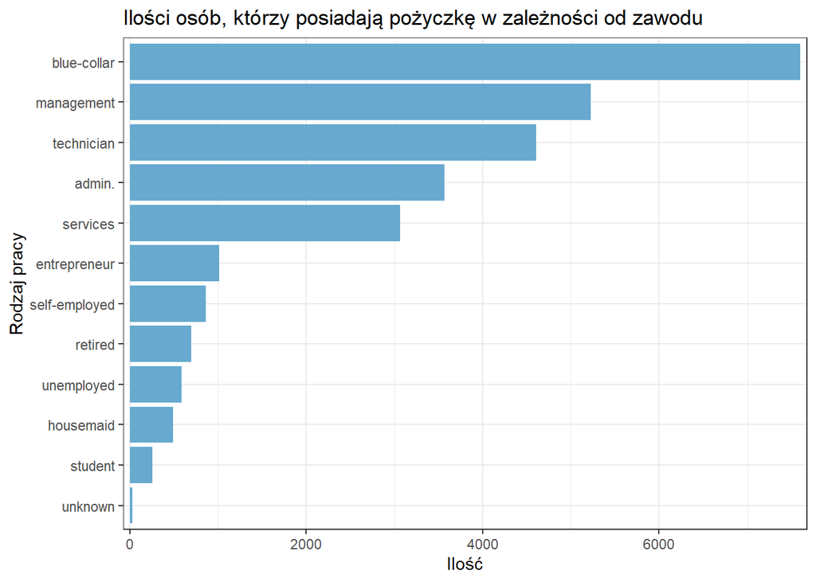

```r
# Tu umieść kod do wygenerowania odpowiedzi do zadania.

df %>%
  filter(loan == "yes" | housing == "yes") %>%
  group_by(job) %>%
  summarize(ilosc = n()) %>%
  mutate(job = forcats::fct_reorder(job, ilosc)) %>%
  ggplot(aes(x = ilosc, y = job)) +
  geom_col(fill = "#67a9cf") +
  theme_bw() +
  labs(x = "Ilość",
       y = "Rodzaj pracy",
       title = "Ilości osób, którzy posiadają pożyczkę w zależności od zawodu") +
  scale_x_continuous(expand = c(0.01, 0.01)) +
  scale_y_discrete(expand = c(0.05, 0.05))
```

**Komentarz:** Widzimy, że zawodem, który najczęściej ma pewien rodzaj zapożyczenia jest “blue-collar”, zaś najrzadziej “zapożyczonym” zawodem jest “unknown”.

## Zadanie 2

Wybierając klientów, którzy mają nieznany sposób kontaktu (`contact`). Jak rozkłada się ich wiek w podziale na status związku?

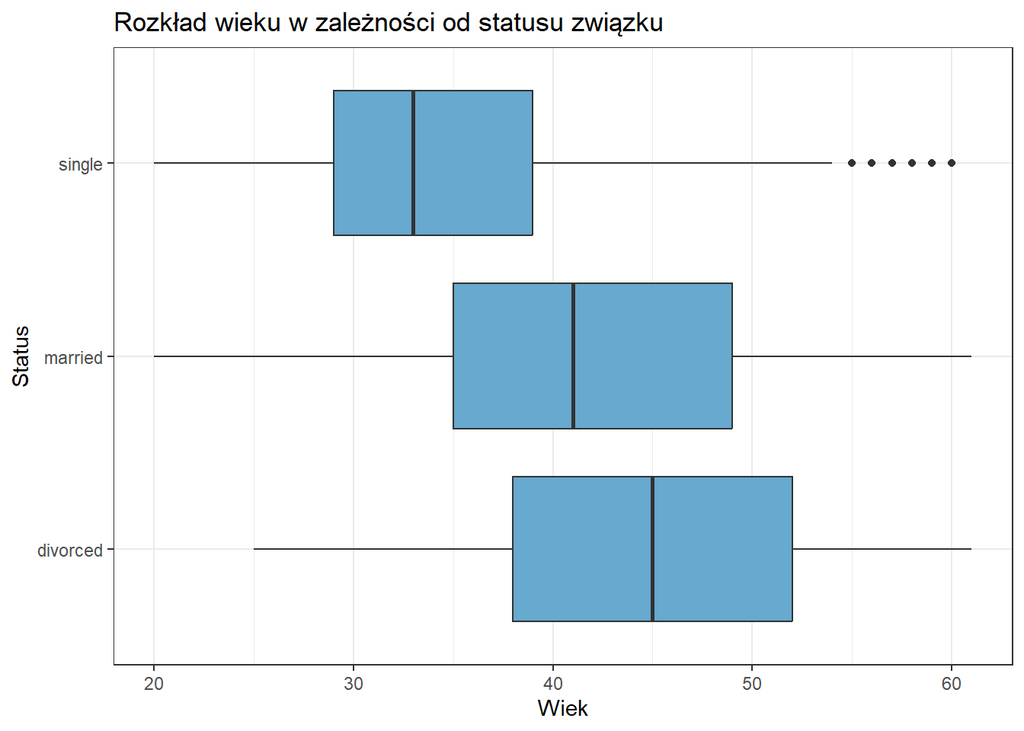

```r
# Tu umieść kod do wygenerowania odpowiedzi do zadania.

df %>%
  filter(contact == "unknown") %>%
  ggplot(aes(x = age, y = marital, fill)) +
  geom_boxplot(fill = "#67a9cf") +
  theme_bw() +
  labs(x = "Wiek",
       y = "Status",
       title = "Rozkład wieku w zależności od statusu związku")
```

**Komentarz:** Widzimy, że połowa osób o statusie “single”, która ma niezdefiniowany sposób kontaktu ma wiek w przedziale [29, 39]. Inaczej sytuacja ta wygląda dla osób o statusie “married” po połowa osób jest w przedziale wiekowym [35, 49]. Najstarsze osoby są o statusie “divorced” bo przedział wiekowy połowy osób. Widzimy także, że spadek liczby osob o statusie “single” wraz ze wzrostem wieku.

## Zadanie 3

Jaka jest różnica pomiędzy średnim rocznym saldem w euro w zależności od wykształcenia i tego czy kredyt jest niespłacany?

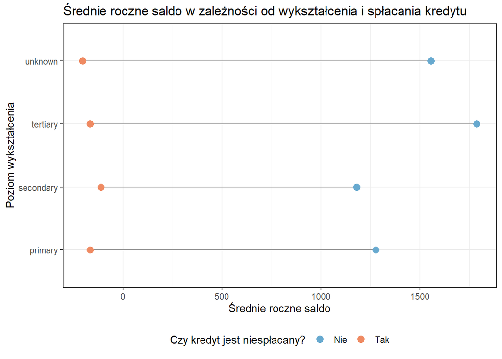

```r
# Tu umieść kod do wygenerowania odpowiedzi do zadania.

df %>%
  group_by(education, default) %>%
  summarize(srednia_zarobki = mean(balance)) %>%
  pivot_wider(names_from = default, values_from = srednia_zarobki) %>%
  ggplot() +
  geom_segment(aes(x = education, y = no, yend = yes), color="#989898") +
  geom_point(aes(x = education, y = no, color = "no"), size=3) +
  geom_point(aes(x = education, y = yes, color = "yes"), size=3) +
  scale_color_manual(name = "Czy kredyt jest niespłacany?",
                     values = c("no" = "#67a9cf", "yes" = "#ef8a62"),
                     labels = c("no" = "Nie", "yes" = "Tak")) +
  coord_flip() +
  theme_bw() +
  labs(x = "Poziom wykształcenia",
       y = "Średnie roczne saldo",
       title = "Średnie roczne saldo w zależności od wykształcenia i spłacania kredytu") +
  theme(legend.position = "bottom")
```

## Zadanie 4

Czy dzień i miesiąc kontaktu z klientem ma wpływ na średni czas trwania rozmowy w stosunku do średniego czasu trwania rozmowy?

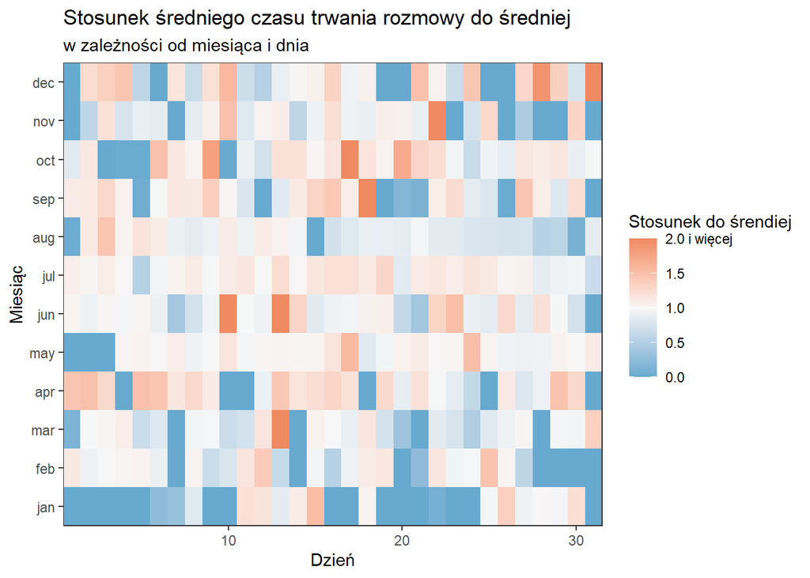

```r
# Tu umieść kod do wygenerowania odpowiedzi do zadania.

miesiace <- c("jan", "feb", "mar", "apr", "may", "jun", "jul", "aug", "sep", "oct", "nov", "dec" )

srednia <- mean(df$duration)

df %>%
  group_by(month, day) %>%
  summarize(srednia_dlugosc = mean(duration)/srednia) %>%
  mutate(month = factor(month, levels = miesiace)) %>%
  pivot_wider(names_from = day, values_from = srednia_dlugosc) -> df_zad4

df_zad4[is.na(df_zad4)] <- 0

df_zad4 %>%
  pivot_longer(!month, names_to = "day", values_to = "srednia_dlugosc") %>%
  mutate(day = as.numeric(day)) %>%
  ggplot(aes(x = day, y = month, fill = srednia_dlugosc)) +
  geom_tile() +
  scale_x_continuous(expand = c(0,0)) +
  scale_y_discrete(expand = c(0,0)) +
  scale_fill_gradient2(
    low = "#67a9cf", mid = "#f7f7f7",high = "#ef8a62",
    midpoint = 1,
    limits = c(0,2),
    oob = scales::squish,
    labels = c("0.0", "0.5", "1.0", "1.5", "2.0 i więcej")
  ) +
  theme_bw() +
  labs(x = "Dzień",
       y = "Miesiąc",
       title = "Stosunek średniego czasu trwania rozmowy do średniej",
       subtitle = "w zależności od miesiąca i dnia",
       fill = "Stosunek do śrendiej") +
  theme(legend.position = "right")
```

**Komentarz:** Widzimy spadek średniego czasu trwania rozmowy w okresie zimowym, czyli w miesiącach od “nov” do “mar” oraz miesiącu “aug”. Wyjątkiem jest koniec “dec”, w którym jest nagły przyrost. W okresie letnim, czyli od “may” do “oct”, bez “aug” czas rozmowy oscyluje wokół średniej z pojedynczymi wyjątkami.

## Zadanie 5

Czy jest zależnośc pomiędzy wiekiem klientów a ich średnim rocznym saldzie w euro w podziale na stopień wykształcenia?

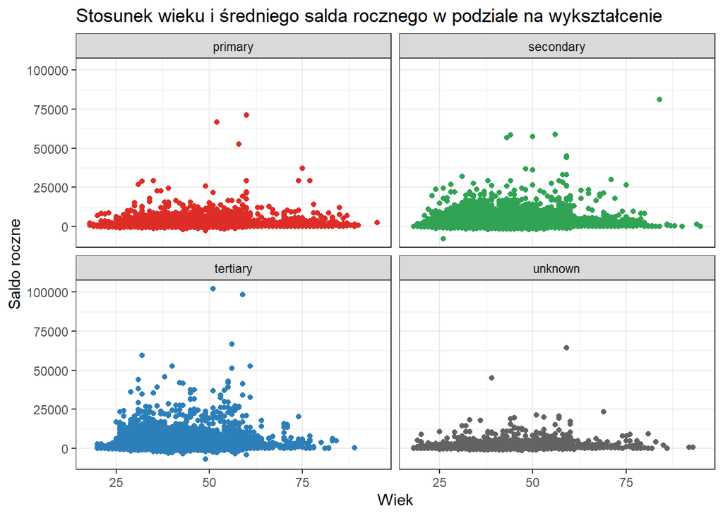

```r
# Tu umieść kod do wygenerowania odpowiedzi do zadania.

df %>%
  ggplot(aes(x = age, y = balance, color = education)) +
  geom_point() +
  facet_wrap(~education) +
  theme_bw() +
  labs(x = "Wiek",
       y = "Saldo roczne",
       title = "Stosunek wieku i średniego salda rocznego w podziale na wykształcenie",
       color = "Wykształcenie") +
  scale_color_manual(values = c("#de2d26", "#31a354", "#2c7fb8", "#636363")) +
  theme(legend.position = "none")
```

**Komentarz:** Widzimy tutaj wzrost zarobków wraz ze wzrostem wykształcenia w grupie wieku produkcyjnego, co wnioskujemy po większym rozrzucie kropek na osi “Saldo roczne”. Najwieksze saldo roczne osiągają osoby o najwyższym wykształceniu.

## Zadanie 6

Rozważmy osoby, które są bezrobotne albo ich zawód jest nieznany. Czy procent osób, które są bezrobotne i nie spłacają kredytu jest większy od procenta osób o nieznanym zawodzie i nie spłacanym kredycie? Jaki typ kredytu jest (przez te osoby) najczęściej niespłacany?

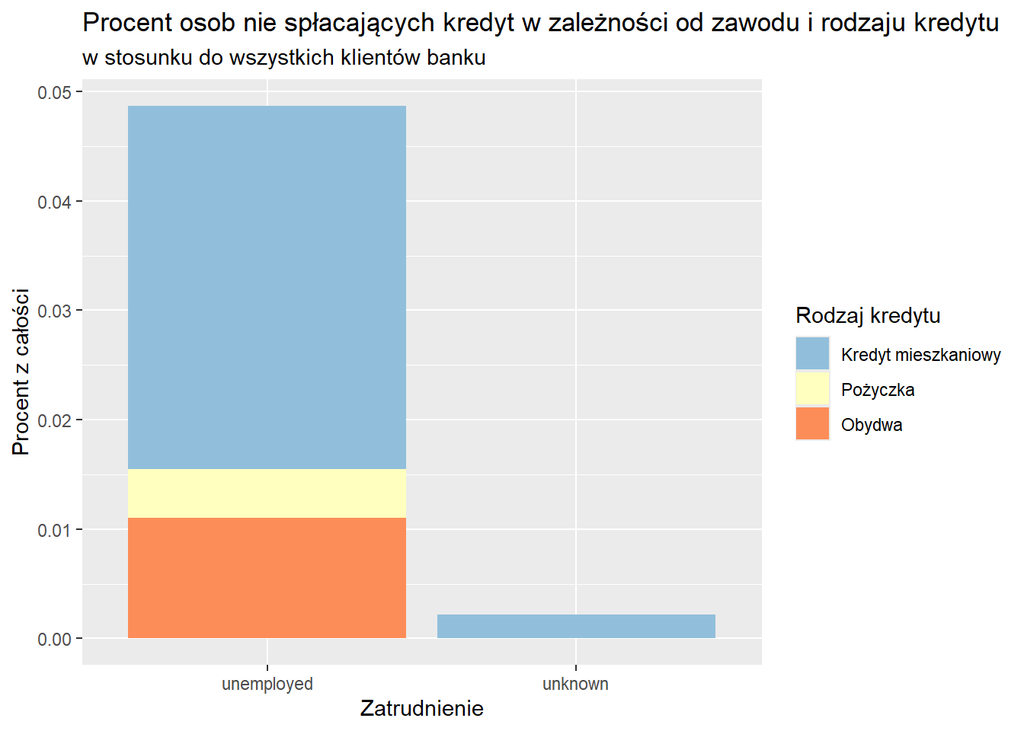

```r
# Tu umieść kod do wygenerowania odpowiedzi do zadania.

ilosc_wszyscy <- dim(df)

df %>%
  mutate(kredyt = as.character((housing == "yes") + 2*(loan == "yes"))) %>%
  filter(job %in% c("unemployed", "unknown"), kredyt != 0, default == "yes") %>%
  group_by(job, kredyt) %>%
  summarize(ilosc = (n()/ ilosc_wszyscy[1]) * 100) %>%
  ggplot(aes(x = job, y = ilosc, fill = kredyt)) +
  geom_col() +
  scale_fill_manual(values = c("#91bfdb", "#ffffbf", "#fc8d59"),
                    labels = c("Kredyt mieszkaniowy", "Pożyczka", "Obydwa")) +
  labs(x = "Zatrudnienie",
       y = "Procent z całości",
       title = "Procent osob nie spłacających kredyt w zależności od zawodu i rodzaju kredytu",
       subtitle = "w stosunku do wszystkich klientów banku",
       fill = "Rodzaj kredytu") +
  theme(legend.position = "right")
```

**Komentarz:** Do uzyskania wykresu nie zostały wliczone osoby, które nie spłacają kredytu oraz nie posiadają kredytu mieszkaniowego lub pożyczki.

Procent osób, które są bezrobotne i nie spłacają kredytu jest większy od procenta osób o nieznanym zawodzie i nie spłacanym kredycie oraz najczęstszym rodzajem zadłużenia jest Kredyt mieszkaniowy. Dużo osób jeżeli decyduje się na pożyczke posiada już kredyt mieszkaniowy lub odwrotnie.